# Scooby-Doo Analysis

Ryan Heslin May 27, 2022

I was scanning the Tidy Tuesday repo for interesting topics, and I couldn’t resist Scooby-Doo.

```r
scoobydoo <- readr::read_csv("https://raw.githubusercontent.com/rfordatascience/tidytuesday/master/data/2021/2021-07-13/scoobydoo.csv", na = "NULL")
glimpse(scoobydoo)
```

```
Rows: 603
Columns: 75
$ index                    <dbl> 1, 2, 3, 4, 5, 6, 7, 8, 9…
$ series_name              <chr> "Scooby Doo, Where Are Yo…
$ network                  <chr> "CBS", "CBS", "CBS", "CBS…
$ season                   <chr> "1", "1", "1", "1", "1", …
$ title                    <chr> "What a Night for a Knigh…
$ imdb                     <dbl> 8.1, 8.1, 8.0, 7.8, 7.5, …
$ engagement               <dbl> 556, 479, 455, 426, 391, …
$ date_aired               <date> 1969-09-13, 1969-09-20, …
$ run_time                 <dbl> 21, 22, 21, 21, 21, 21, 2…
$ format                   <chr> "TV Series", "TV Series",…
$ monster_name             <chr> "Black Knight", "Ghost of…
$ monster_gender           <chr> "Male", "Male", "Male", "…
$ monster_type             <chr> "Possessed Object", "Ghos…
```

[output cut: 62 more lines]

```r
theme_standard <- ggplot2::theme(
  panel.background = element_blank(),
  panel.border = element_rect(color = "black", fill = NA),
  panel.grid = element_blank(), panel.grid.major.x = element_line(
    color =
      "gray93"
  ),
  legend.background = element_rect(fill = "gray93"), plot.title = element_text(
    size = 15,
    family = "sans", face = "bold", vjust = 1.3
  ), plot.title.position =
    "plot",
  plot.subtitle = element_text(size = 10, family = "sans"),
  legend.title = element_text(
    size = 10, family = "sans",
    face = "bold"
  ), axis.title = element_text(
    size = 9,
    family = "sans", face = "bold"
  ), axis.text = element_text(
    size = 8,
    family = "sans"
  ), strip.background = element_rect(
    color = "black",
    fill = "black"
  ), strip.text.x = element_text(color = "white"),
  strip.text.y = element_text(color = "white")
)
ggplot2::theme_set(theme_standard)
```

After skimming the variable list, my attention inevitably lands on the `scrappy_doo` indicator. While I sadly am not versed in Scooby-Doo lore, I know Scrappy is widely disliked.

```r
logicals <- map_lgl(scoobydoo, ~ any(.x %in% c("TRUE", "FALSE")))
scoobydoo <- mutate(scoobydoo, across(which(logicals), as.logical))
```

```r
t.test(imdb ~ scrappy_doo, data = scoobydoo)
```

```
    Welch Two Sample t-test

data:  imdb by scrappy_doo
t = 2.1906, df = 585.7, p-value = 0.02888
alternative hypothesis: true difference in means between group FALSE and group TRUE is not equal to 0
95 percent confidence interval:
 0.01093575 0.20055791
sample estimates:
mean in group FALSE  mean in group TRUE
           7.307565            7.201818
```

He appears in 27% of episodes.

To my surprise, there are 112 episodes with a real monster.

The highest-rated episode is a crossover with *Supernatural*, which makes sense.

```r
arrange(scoobydoo, -imdb) |>
  pull(title) |>
  head(10)
```

```
 [1] "Scoobynatural"             "Come Undone"
 [3] "All Fear the Freak"        "Night Terrors"
 [5] "Through the Curtain"       "Wrath of the Krampus"
 [7] "The Man in the Mirror"     "Nightmare in Red"
 [9] "Escape from Mystery Manor" "Pawn of Shadows"
```

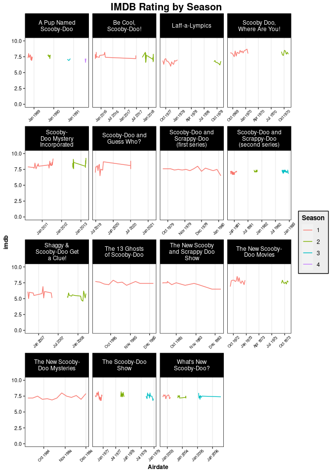

```r
filter(scoobydoo, !season %in% c("Crossover", "Movie", "Special")) |>
  mutate(series_name = str_wrap(series_name, 15)) |>
  ggplot(aes(x = date_aired, y = imdb)) +
  geom_line(aes(color = season)) +
  facet_wrap(. ~ series_name, scales = "free_x") +
  scale_x_date(date_labels = "%b %Y") +
  labs(x = "Airdate", color = "Season", title = "IMDB Rating by Season") +
  ylim(c(0, 10)) +
  theme(axis.text.x = element_text(size = 6, angle = 45))
```

The main story of this plot is that Shaggy really likes to say “Zoinks!” They also seem to have toned down the catchphrases in later seasons.

[figure not shown]

```r
phrase_vars <- quote(split_up:rooby_rooby_roo)
scoobydoo |>
  filter(!season %in% c("Crossover", "Movie", "Special")) |>
  group_by(season) |>
  summarize(across(!!phrase_vars, sum, na.rm = TRUE)) |>
  pivot_longer(!!phrase_vars, names_to = "Phrase", values_to = "Count") |>
  mutate(
    Phrase = paste0('"', str_replace_all(str_to_title(Phrase), "_", " "), '!"') |> str_wrap(width = 10),
    Count = ifelse(is.na(Count), 0, Count)
  ) |>
  ggplot(aes(x = Phrase, y = season, fill = Count)) +
  geom_tile(color = "white") +
  scale_x_discrete(expand = c(0, 0)) +
  scale_y_discrete(expand = c(0, 0)) +
  scale_fill_gradient(low = "purple", high = "green", trans = "log10", oob = scales::squish_infinite) +
  labs(title = "Phrases Uttered by Season", y = "Season") +
  guides(fill = guide_legend(
    title.position = "top",
    title.hjust = .5
  )) +
  theme(
    legend.position = "bottom",
    axis.text.x = element_text(size = 8),
    axis.title.x = element_blank(),
    axis.ticks.x = element_blank(),
    plot.title = element_text(hjust = .5),
    legend.background = element_rect(fill = "gray")
  )
```

It seems that “competition” as a villain motive waxed and waned the most over time, peaking in the 1990s. An interesting direction for further analysis.

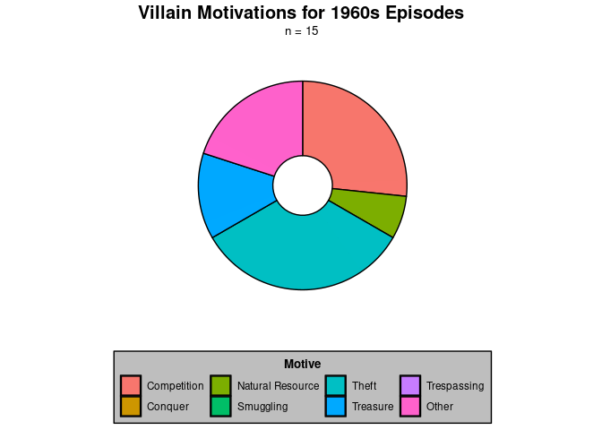

```r
library(gganimate)

year_to_decade <- function(dates) {
  lubridate::year(dates) |>
    as.numeric() |>
    (function(x) x - x %% 10)() |>
    paste0("s")
}
# https://stackoverflow.com/questions/52403952/polar-plot-ggplot2-outer-ring-removed-grid-on-top
scoobydoo <- scoobydoo |>
  mutate(
    decade = year_to_decade(date_aired),
    decade_count = ave(decade, decade, FUN = length) |> as.integer(),
    motive = fct_lump_prop(motive, prop = .02)
  )

p <- scoobydoo |>
  filter(!is.na(motive), !is.na(date_aired)) |>
  group_by(decade) |>
  count(motive, name = "Proportion") |>
  mutate(
    Proportion = Proportion / sum(Proportion),
    ymax = cumsum(Proportion),
    ymin = dplyr::lag(ymax, default = 0),
  ) |>
  ungroup() |>
  ggplot(aes(xmin = 1, xmax = 3.5, ymin = ymin, ymax = ymax, fill = motive)) +
  geom_rect(color = "black") +
  coord_polar(theta = "y") +
  xlim(c(0, 4)) +
  guides(fill = guide_legend(
    title.position = "top",
    title.hjust = .5
  )) +
  labs(fill = "Motive") +
  theme(
    legend.position = "bottom",
    axis.text.x = element_blank(),
    axis.text.y = element_blank(),
    axis.title.x = element_blank(),
    axis.title.y = element_blank(),
    axis.ticks.x = element_blank(),
    axis.ticks.y = element_blank(),
    legend.key = element_rect(fill = "gray"),
    legend.background = element_rect(fill = "gray"),
    line = element_blank(),
    panel.grid.major.x = element_blank(),
    panel.border = element_blank(),
    plot.title = element_text(hjust = .5),
    plot.subtitle = element_text(hjust = .5)
  )
p + transition_states(decade,
  transition_length = 1, state_length = 3, wrap = TRUE
) +
  ease_aes("linear") +
  enter_drift() +
  exit_drift() +
  ggtitle(label = "Villain Motivations for {closest_state} Episodes", subtitle = paste("n = {scoobydoo |> filter(decade == closest_state)  |> pull(decade_count)  |> unique()}"))
```